# Final Project Report

# Introduction

Fertility issues are extremely common, with approximately 1 in 6 adults experiencing fertility challenges [2]. In vitro fertilization (IVF) is a common treatment option for such cases. However, IVF success rates remain relatively low [3]. While much of the research on poor IVF outcomes has focused on maternal stressors and periconceptional health, paternal factors, particularly alcohol consumption, have received comparatively less attention.

In the United States, alcohol use is widespread, yet most studies investigating the impact of alcohol on IVF outcomes emphasize maternal drinking or are confounded by multiple lifestyle variables [1]. This report aims to examine the effects of paternal alcohol consumption on IVF embryo development.

To explore this question, paternal mice were exposed to either an alcohol-free solution or a 10% ethanol solution for 10 weeks. Sperm from these males was then used to fertilize oocytes retrieved from alcohol-free females. The resulting embryos were cultured to the morula stage, after which total RNA was harvested for gene expression analysis.

The central hypothesis is that embryonic gene expression is altered in embryos derived from alcohol-exposed fathers compared to controls, specifically with gene expression changes of Fgf4 and Egfr.

## Dataset

[Dataset](https://www.ncbi.nlm.nih.gov/geo/query/acc.cgi?acc=GSE214726)

- The data is linked to the following publication - [Preconception paternal alcohol exposure decreases IVF embryo survival and pregnancy success rates in a mouse model](https://pmc.ncbi.nlm.nih.gov/articles/PMC9907225/).
- The data was generated by the Golding Lab at Texas A&M University in the department of Veterinary Physiology & Pharmacology.
- The RNA was extracted using the Quick Biololgy Inc. RNA isolation protocol. [Source](https://www.ncbi.nlm.nih.gov/geo/query/acc.cgi?acc=GSM6615000)
- The library was prepped using the Quick Biololgy Inc. library construction protocol. [Source](https://www.ncbi.nlm.nih.gov/geo/query/acc.cgi?acc=GSM6615000)
- The experimental treatment/condition was defined by the Nakagata IVF protocol with CARD media. This is a method for extracting embryos from mice as defined in this [paper](https://pubmed.ncbi.nlm.nih.gov/30353518/). [Source](https://www.ncbi.nlm.nih.gov/geo/query/acc.cgi?acc=GSM6615000)
- The Illumina NovaSeq 6000 platform was used for sequencing.
- There are 3 samples per condition (Experimental: 10% Alcohol Paternal Exposure, WT: Alochol Free Paternal Exposure)
- The data is paired-end
- The library is unstranded (as found through IGV)

# Results

Github for report: https://github.com/naraharip2017/ANGSD-pan4008/tree/main

Run scripts in following order to reproduce results in report:

1. download_samples.sh
2. run_preprocessing_fastqc.sh
3. trim_samples_run_fastqc.sh
4. align_reads.sh
5. run_feature_counts.sh
6. run_rseqc.sh

Through differential gene expression analysis, the hypothesis was supported that there were differences in transcript composition between embryos fertilized from paternal fathers that were exposed to alcohol and those that were not. Additionally, as hypothesized there was a downregulation in Fgf4 (Fibroblast growth factor 4) and Egfr (Epidermal growth factor), which are both critical regulators of trophectoderm stem cell growth and placental patterning [3]. Along with similar findings to the paper that utilized this dataset, I also found differential gene expression of Gm14137 and Gbp10, both of which are believed to impact GTP binding activity [4][5]. The GO enrichment analysis also found changes in expression around development, specifically with the eyes and sensory systems. Through this analysis, it is clear paternal consumption of alcohol impacts development of a fertilized embryo. Further experiments could be conducted to perform direct KO of the genes differentially expressed in this report and directly monitor phenotypic changes to further understand their impact on a growing embryo.

There are several limitations from the findings in this report. For example, the library was prepped using totalRNA, which captures abundant mRNA along with other non-protein coding RNAs. Additionally, as seen in the RSeQC results, there may be some degradation of transcripts causing a 3’ bias and impacting what is seen in the results. Furthermore, after normalizng reads across samples, there was a lack of clustering between WT and EXP samples. This could be a result of low variance between the samples or issues with sample size, normalization, or technical issues. Finally, since the experiments were conducted on mice, it is difficult to know if the findings would translate well to humans and how embryos from different species would be impacted.

# Methods

## Generating Alignment and Read Counts

### Downloading data

I first downloaded the data to my workspace using this [script](https://github.com/naraharip2017/ANGSD-pan4008/blob/main/scripts/download_samples.sh)

This created the directory structure with the `SRR ID` and sample type (experimental, WT) for tracking of the type of sample. Since the reads are paired-end there are two files per condition.

```
SRR21798749_EXP1  SRR21798750_EXP2  SRR21798751_EXP3  SRR21798755_WT1  SRR21798756_WT2  SRR21798757_WT3
```

```bash
cd SRR21798749_EXP1
ls
```

```
SRR21798749_1.fastq.gz  SRR21798749_2.fastq.gz
```

### Pre-processing Data

Before performing alignments, I performed some quality control on the read files themselves. I first performed `fastqc` on the raw reads. I used two threads to process the two reads from paired-end reads. I used this [script](https://github.com/naraharip2017/ANGSD-pan4008/blob/main/scripts/run_preprocessing_fastqc.sh) to generate the fastqc reports

I ran multiqc on the generated `fastqc` report. I excluded those in the `trimmed` explicitly since I ran `multiqc` on the pre-processed samples after trimming an initial couple samples

```bash
multiqc $(find . -type d -name "*_fastqc" -not -path "*/trimmed/*") -o multiqc_report
```

Investigating the reports, there were 0 sequences flagged for bad quality but there was adapter contamination and some sequence duplication.

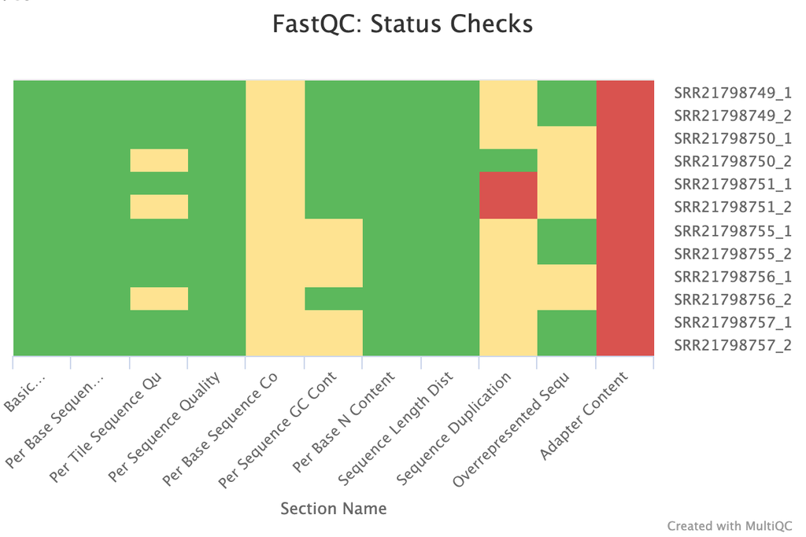

Figure 1: Multiqc for all pre-processed samples

```r
knitr::include_graphics("figure_imgs/pre_processed_multiqc.png")
```

I then ran the following [script](https://github.com/naraharip2017/ANGSD-pan4008/blob/main/scripts/trim_samples_run_fastqc.sh) which did the following steps:

1. `trim_galore` to remove the adapters from the reads. I passed Illumina because I knew that the sequencing was done on an Illumina platform. I outputted to a `trimmed/` directory per sample.
2. `fastqc` was run on the trimmed samples and reports were investigated after to ensure samples removed adapters properly

I then ran multiqc to concantenate the results of the reports. I explicitly used the trimmed directories in each sample to generate results for the post-adapter trimmed reports

```bash
multiqc $(find . -type d -path "*/trimmed/*_fastqc") -o multiqc_report_trimmed
```

After performing `fastqc` on the trimmed reads, the reports indicated adapters were removed and 0 poor quality reads still. However, the reports indicated `FAIL` for `Per base sequence content` so that may indicate a source of bias or error in subsequent analysis. Though looking at the plots for the samples, as shown in Figure 3, there seems to be a false failure, as trim-galore will often remove the poly-A tail as a result of matching with illumina adapters [Source](https://github.com/FelixKrueger/TrimGalore/issues/81).

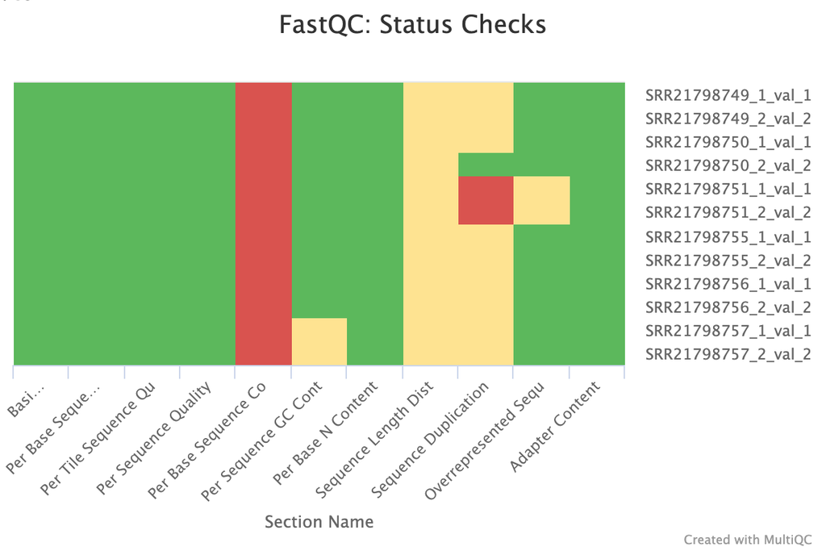

Figure 2: Multiqc for all post-trimmed samples

```r
knitr::include_graphics("figure_imgs/post_trimmed_multiqc.png")
```

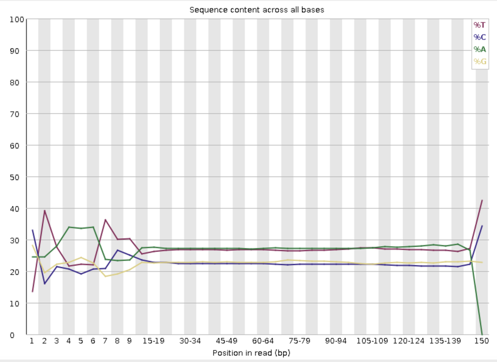

Figure 3: Example Post Trimmed FastQC report Per Base Sequence Content - sample SRR21798749_EXP1

```r
knitr::include_graphics("figure_imgs/per_base_sequence_content.png")
```

For the one sample that failed sequence duplication, I checked it’s `FastQC` report and found that the overrepresented sequence is `CCCGGCTATCCGGGGCCAACCGAGGCTCCTTCGGCGCTGCCGTATCGTTC`. I ran the sequence through [BLAST](https://blast.ncbi.nlm.nih.gov/Blast.cgi?CMD=Web&PAGE_TYPE=BlastSearch&VIEW_SEARCH=on&UNIQ_SEARCH_NAME=A_SearchOptions_1u7Q4m_jVR_dePhsmvIFqaa_GTJ71_2DnHNF) and found it was rRNA. The original paper did not remove rRNA, so I kept it in the library for subsequent analysis.

### Creating Reference Genome

I downloaded a reference genome from ucsc as the publication linked to the dataset retrieved their data from the `UCSC m39` reference genome. I downloaded the `.fa` file and `.gtf` files from the following locations

```bash
wget ftp://hgdownload.soe.ucsc.edu/goldenPath/mm39/bigZips/mm39.fa.gz
```

```bash
wget ftp://hgdownload.soe.ucsc.edu/goldenPath/mm39/bigZips/genes/refGene.gtf.gz
```

I then created a reference genome to perform an alignment for the RNA data

```bash
STAR --runMode genomeGenerate --runThreadN 10 --genomeDir Mus_musculusSTARindex/ --genomeFastaFiles mm39.fa --sjdbGTFfile refGene.gtf --sjdbOverhang 149
```

I used a sjdbOverhang of 149 because the length of the reads in my dataset are 150, and the help menu says to use `readLength-1` for the parameter

### Aligning Samples

I then ran the following [script](https://github.com/naraharip2017/ANGSD-pan4008/blob/main/scripts/align_reads.sh) to perform the alignment between the trimmed samples and the reference genome. I passed the parameter `--alignIntronMax 100000` so that reads that map to large intron junction as a technical artifact are removed from the mappings.

### Feature counts

I then ran the following [script](https://github.com/naraharip2017/ANGSD-pan4008/blob/main/scripts/run_feature_counts.sh) to run `featureCounts` to attribute genes to the generated alignments. I passed the parameters `-Q 10` to consider a minimum mapping quality per read of 10 to stay in line with the process from the original paper. I used the `refGene.gtf` from UCSC and passed `-p` and `--countReadPairs` to properly handle the paired-end reads. `-T 8` was passed to use additional threads.

The `featureCounts` produced a `musmusculus_fc.txt` output, which I then used for subsequent differential gene expression investigations.

### Alignment QC

Prior to performing differential gene expression analysis, I performed QC on the generated alignments for each sample. I first manually investigated the STAR `Log.Final.Out` and found most samples aligned ~60-70% of their reads uniquely.

I then ran `rseqc`, which required a BED file for the reference genome rather than a `.gtf` file. I utilized `UCSC` tools to generate a BED file from the earlier downloaded `refGene.gtf.gz` file.

```bash
conda create --name pan4008 python=3.10
conda install -c bioconda ucsc-gtftogenepred ucsc-genepredtobed
gtfToGenePred refGene.gtf refGene.genePred
genePredToBed refGene.genePred refGene.bed
```

After creating the BED file, I then performed `rseqc` analysis on the aligned reads and the BED file through this [script](https://github.com/naraharip2017/ANGSD-pan4008/blob/main/scripts/run_rseqc.sh), and then ran multiqc for the read distribution and gene body coverage plots

```bash
cd rseqc
conda activate multiqc
multiqc .
```

[figure not shown]

Figure 4: RSEQC Read Distribution Plot

```r
knitr::include_graphics("figure_imgs/rseqc_read_distribution_plot.png")
```

The read distribution plot shows some intergenic reads, showing a potential source of low quality reads.

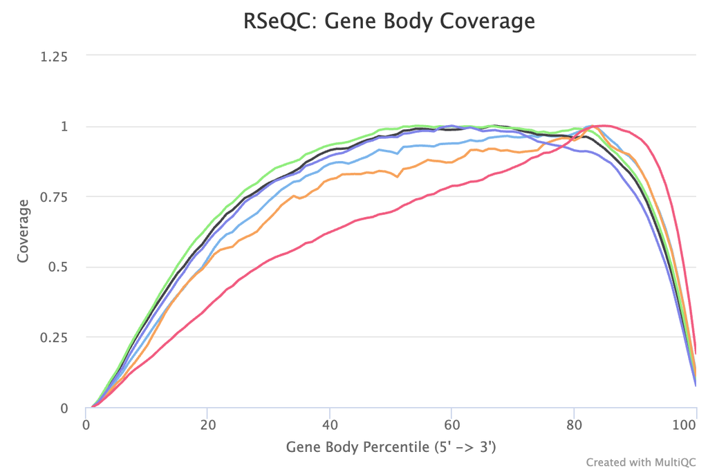

Figure 5: RSEQC Gene Body Coverage Plot

```r
knitr::include_graphics("figure_imgs/rseqc_gene_body_coverage_plot.png")
```

The gene body coverage plot shows some bias towards the 3’ end showing there may be some mRNA degradation occurring or batch effect, which was captured in the library.

Using the `featureCounts` summary file, I then plotted the aligned reads per sample to make sure most were aligned. As Figure 6 shows, there looks to be some reads that were multimapped, ambiguous, or no features, which is something that may have impacted subsequent analysis.

```r
process_data_for_ggplot <- function(file, filter_categories) {
  summary_data <- read.table(file, header=TRUE, row.names = 1, sep = "\t")
  transposed_data <- as.data.frame(t(summary_data))
  transposed_data$Sample <- rownames(transposed_data)
  rownames(transposed_data) <- NULL
  transposed_data <- transposed_data %>% relocate(Sample)

  long_data <- transposed_data %>%
  pivot_longer(cols = -Sample,
               names_to = "Status",
               values_to = "Counts")

    sample_mapping <- c(
    "SRR21798749.SRR21798749.Aligned.sortedByCoord.out.bam" = "SRR21798749_EXP1",
    "SRR21798750.SRR21798750.Aligned.sortedByCoord.out.bam" = "SRR21798750_EXP2",
    "SRR21798751.SRR21798751.Aligned.sortedByCoord.out.bam" = "SRR21798751_EXP3",
    "SRR21798755.SRR21798755.Aligned.sortedByCoord.out.bam" = "SRR21798755_WT1",
    "SRR21798756.SRR21798756.Aligned.sortedByCoord.out.bam" = "SRR21798756_WT2",
    "SRR21798757.SRR21798757.Aligned.sortedByCoord.out.bam" = "SRR21798757_WT3"
  )

  long_data$Sample <- recode(long_data$Sample, !!!sample_mapping)

  long_data <- long_data %>%
    filter(Status %in% filter_categories)

  return(long_data)
}
```

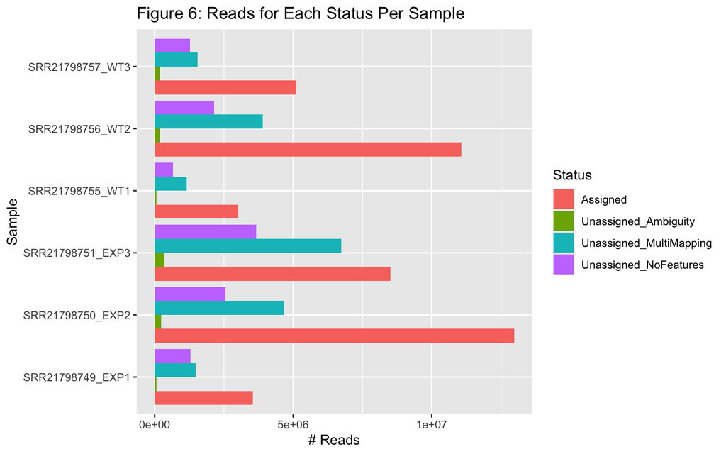

```r
gene_count_data = process_data_for_ggplot("musmusculus_fc.txt.summary", c("Assigned", "Unassigned_Ambiguity", "Unassigned_NoFeatures", "Unassigned_MultiMapping"))

plot <- ggplot(gene_count_data, aes(x = Counts, y = Sample, fill = Status)) +
  geom_bar(stat = "identity", position = "dodge") +
  labs(x = "# Reads", y = "Sample", title = "Figure 6: Reads for Each Status Per Sample")

plot
```

## Reading Data into R and Post Alignment Processing

I first began by reading the `featureCounts` dataframe into R and generating plots to view differences in sequencing depths. While I do some processing to normalize the sequencing depth, I did not conduct further investigations, as the normalization was merely for data exploration. The subsequent differential gene expression is done on the raw read counts.

```r
df_counts <- read.table("musmusculus_fc.txt", header = TRUE)
new_names <- c(names(df_counts)[1:6], paste("EXP", c(1:3), sep = "_"), paste("WT", c(1:3), sep = "_"))
names(df_counts) <- new_names
str(df_counts)
```

```
## 'data.frame':    26264 obs. of  12 variables:
##  $ Geneid: chr  "Xkr4" "Rp1" "Sox17" "Mrpl15" ...
##  $ Chr   : chr  "chr1;chr1;chr1" "chr1;chr1;chr1;chr1;chr1;chr1;chr1;chr1;chr1;chr1;chr1;chr1;chr1;chr1;chr1;chr1;chr1;chr1;chr1;chr1;chr1;chr1;c"| __truncated__ "chr1;chr1;chr1;chr1;chr1;chr1;chr1;chr1;chr1;chr1;chr1;chr1;chr1;chr1;chr1;chr1;chr1;chr1;chr1;chr1" "chr1;chr1;chr1;chr1;chr1;chr1;ch…
##  $ Start : chr  "3284705;3491925;3740775" "4190089;4212835;4218035;4218835;4234078;4240428;4267757;4276883;4296834;4298666;4301276;4313356;4313640;4313766"| __truncated__ "4561151;4561151;4561151;4561151;4561151;4563323;4563323;4563995;4563995;4563995;4563995;4563995;4565359;4565359"| __truncated…
##  $ End   : chr  "3287191;3492124;3741721" "4190296;4212989;4218186;4218967;4234164;4240627;4267864;4277060;4297046;4298842;4301367;4313485;4313671;4313842"| __truncated__ "4562891;4562891;4562891;4562891;4562891;4563689;4563713;4564086;4564086;4564086;4564086;4564086;4566165;4566165"| __truncated…
##  $ Strand: chr  "-;-;-" "-;-;-;-;-;-;-;-;-;-;-;-;-;-;-;-;-;-;-;-;-;-;-;-;-;-;-;-;-;-;-" "-;-;-;-;-;-;-;-;-;-;-;-;-;-;-;-;-;-;-;-" "-;-;-;-;-;-;-;-;-;-;-;-;-;-" ...
##  $ Length: int  3634 12293 4095 4203 2503 2847 2513 2063 4707 3692 ...
##  $ EXP_1 : int  0 0 0 2283 681 516 0 490 0 1 ...
##  $ EXP_2 : int  0 0 1 6430 4489 2369 0 1392 0 0 ...
##  $ EXP_3 : int  0 0 0 3526 2772 1472 0 1086 0 0 ...
##  $ WT_1  : int  0 0 0 1257 491 389 0 230 0 0 ...
##  $ WT_2  : int  0 0 11 2695 2730 1186 1 1459 0 0 ...
##  $ WT_3  : int  0 0 0 1380 1075 932 0 659 0 0 ...
```

```r
row.names(df_counts) <- make.names(df_counts$Geneid)
cts_gene_sample <- df_counts[ , -c(1:6)]
head(cts_gene_sample)
```

```
##        EXP_1 EXP_2 EXP_3 WT_1 WT_2 WT_3
## Xkr4       0     0     0    0    0    0
## Rp1        0     0     0    0    0    0
## Sox17      0     1     0    0   11    0
## Mrpl15  2283  6430  3526 1257 2695 1380
## Lypla1   681  4489  2772  491 2730 1075
## Tcea1    516  2369  1472  389 1186  932
```

```r
df_coldata <- data.frame(condition = gsub("_[0-9]+", "", names(cts_gene_sample)),
row.names = colnames(cts_gene_sample))
```

```r
dds_musmusculus <- DESeqDataSetFromMatrix(countData = cts_gene_sample,
colData = df_coldata,
design = ~ condition)
df_rowdata <- df_counts[, 1:6]
rowData(dds_musmusculus) <- df_rowdata
dds_musmusculus
```

```
## class: DESeqDataSet
## dim: 26264 6
## metadata(1): version
## assays(1): counts
## rownames(26264): Xkr4 Rp1 ... Vmn2r122 Kcnc3
## rowData names(6): Geneid Chr ... Strand Length
## colnames(6): EXP_1 EXP_2 ... WT_2 WT_3
## colData names(1): condition
```

```r
keep_genes <- rowSums(counts(dds_musmusculus)) > 0
dds_musmusculus <- dds_musmusculus[ keep_genes, ]
dim(dds_musmusculus)
```

```
## [1] 16314     6
```

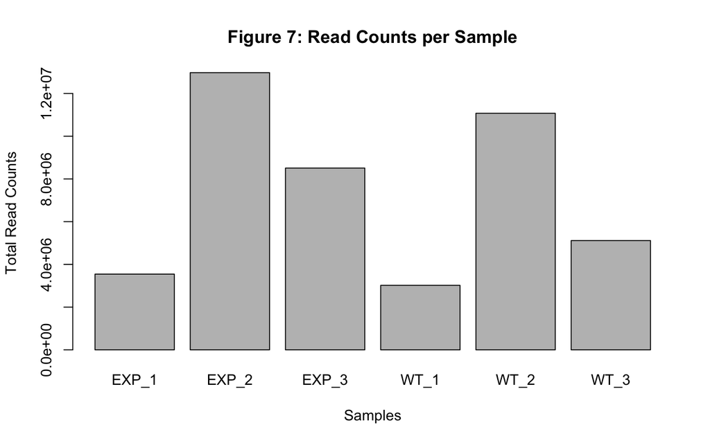

```r
colSums(counts(dds_musmusculus)) %>%
  barplot(main = "Figure 7: Read Counts per Sample", xlab = "Samples", ylab = "Total Read Counts")
```

As Figure 7 shows, there is a clear imbalance in sequencing depth across samples. As part of data exploration, I then performed some normalization of the read counts.

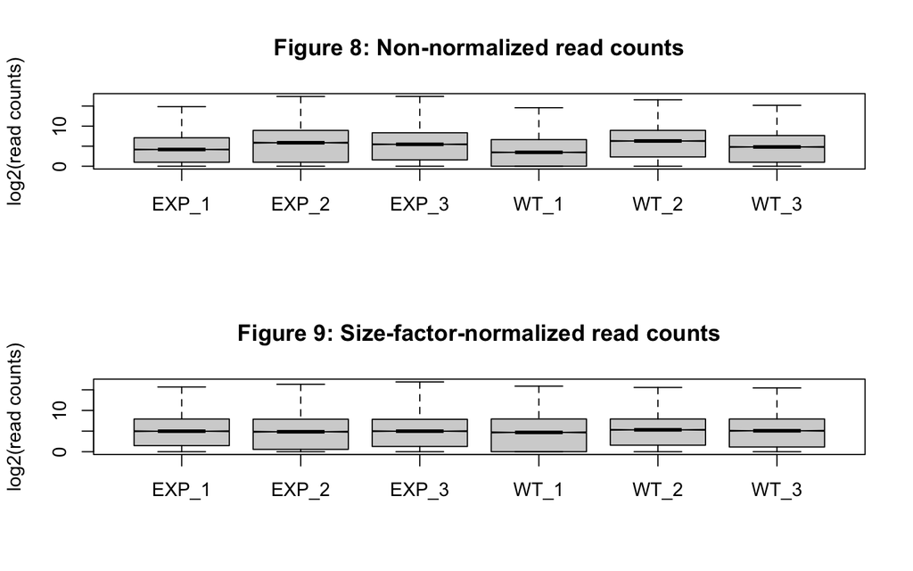

```r
dds_musmusculus <- estimateSizeFactors(dds_musmusculus)
par(mfrow=c(2,1))
counts.sf_normalized <- counts(dds_musmusculus, normalized=TRUE)

boxplot(log2(counts(dds_musmusculus) +1), notch=TRUE,
main = "Figure 8: Non-normalized read counts",
ylab ="log2(read counts)", cex = .6)
boxplot(log2(counts(dds_musmusculus, normalized=TRUE) +1), notch=TRUE,
main = "Figure 9: Size-factor-normalized read counts",
ylab ="log2(read counts)", cex = .6)
```

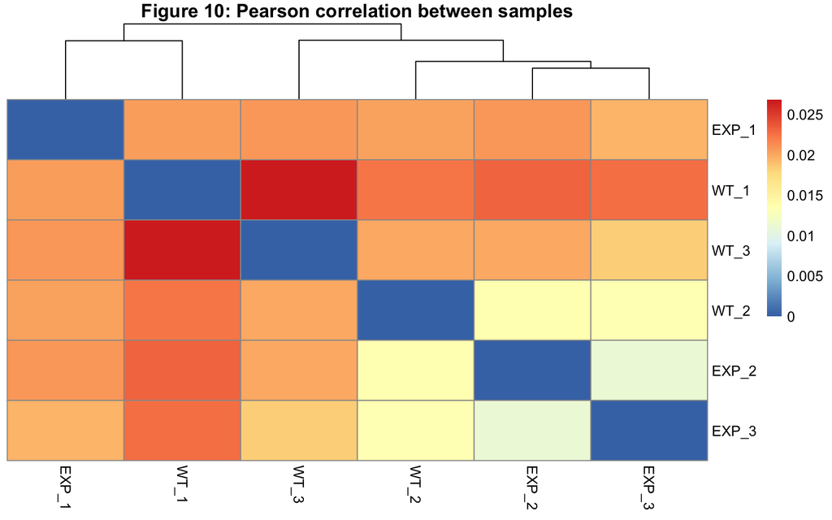

```r
log_counts <- log2(counts(dds_musmusculus, normalized = FALSE) + 1)
assay(dds_musmusculus, "log_counts") <- log2(counts(dds_musmusculus, normalized = FALSE) + 1)
assay(dds_musmusculus, "log_norm_counts") <- log2(counts(dds_musmusculus, normalized=TRUE) + 1)

dst_rlog <- rlog(dds_musmusculus, blind = TRUE)

rlog_norm_counts <- assay(dst_rlog)

corr_coeff <- cor(rlog_norm_counts, method ="pearson")
as.dist(1-corr_coeff, upper=TRUE) %>%
as.matrix %>%
pheatmap::pheatmap(main="Figure 10: Pearson correlation between samples",
treeheight_row=0)
```

```
## using ntop=500 top features by variance
```

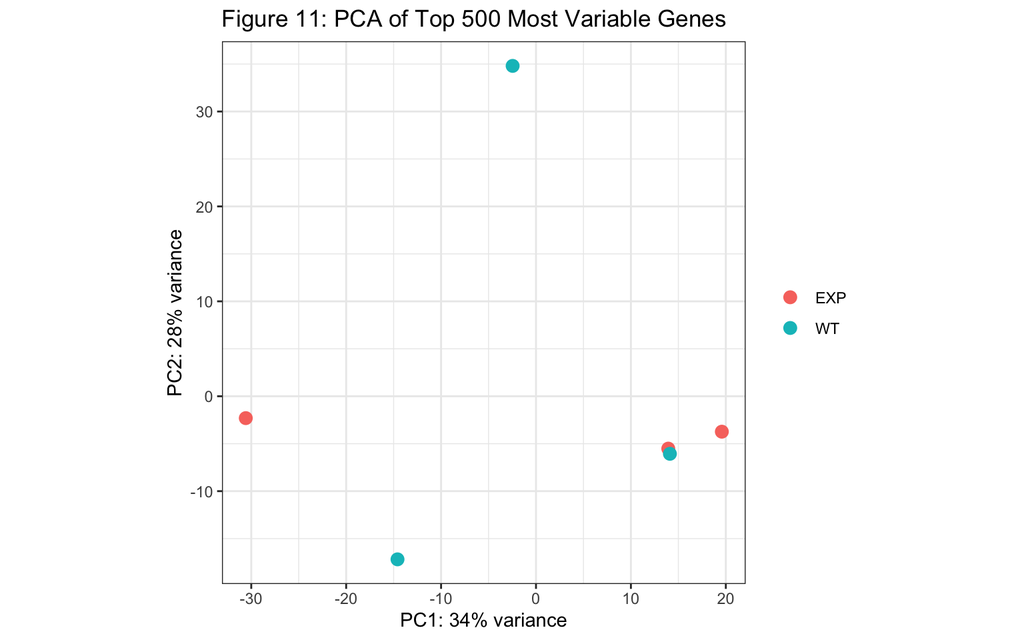

```r
rv <- rowVars(rlog_norm_counts)
top_variable <- order(rv, decreasing = TRUE)[seq_len(500)]
pca <- prcomp(t(rlog_norm_counts[top_variable, ]))
plotPCA(dst_rlog) +
labs(color=NULL) +
theme_bw() +
ggtitle("Figure 11: PCA of Top 500 Most Variable Genes")
```

Both the Pearson Plot and PCA were unable to cluster the WT and EXP samples well. This may be due to low sample size or normalization removing bioligical signal.

### Run differential gene expression analysis with DESeq2

After loading and exploring the data, I then ran differential gene expression analysis using the created `DESeq2` object

```r
dds_musmusculus$condition %<>% relevel(ref="WT")

dds_musmusculus <- DESeq(dds_musmusculus)
DGE_results <- results(dds_musmusculus,
                       independentFiltering = TRUE,
                       alpha = 0.05,
                       saveCols="Length")
gene_list <- DGE_results$log2FoldChange
names(gene_list) <- rownames(DGE_results)
gene_list <- sort(gene_list, decreasing = TRUE)
```

Results were subsetted to just those genes whose adjusted p-values (after multiple hypothesis correction) pass the statistical threshold of 0.05. These are the genes that are labeled as differentially expressed.

```r
DGE_genes <- subset(DGE_results, padj < 0.05)
DGE_genes <- DGE_genes[order(DGE_genes$padj), ]

num_deg <- nrow(DGE_genes)
print(paste("Number of differentially expressed genes (padj < 0.05):", num_deg))
```

```
## [1] "Number of differentially expressed genes (padj < 0.05): 19"
```

```r
total_genes <- nrow(DGE_results)

deg_proportion <- num_deg / total_genes
print(paste("Proportion of differentially expressed genes:", round(deg_proportion, 4)))
```

```
## [1] "Proportion of differentially expressed genes: 0.0012"
```

Similar to the paper, a low amount of genes were found to be differentially expressed between WT and EXP conditions. In the paper the authors relaxed the p-value 0.05 threshold for subsequent analysis, but for the purposes of this report only analysis was conducted on the stringent threshold.

```r
top5_genes <- head(DGE_genes, 5)
knitr::kable(top5_genes, caption = "Table 2: Top 5 Differentially Expressed Genes (sorted by adjusted p-value)")
```

Table 2: Top 5 Differentially Expressed Genes (sorted by adjusted p-value)

|  | baseMean | log2FoldChange | lfcSE | stat | pvalue | padj | Length |
| --- | --- | --- | --- | --- | --- | --- | --- |
| Gm14137 | 29.17451 | -22.767970 | 3.9088835 | -5.824674 | 0.00e+00 | 0.0000304 | 3060 |
| Gbp10 | 31.22906 | -22.858230 | 3.9087440 | -5.847973 | 0.00e+00 | 0.0000304 | 3528 |
| Fgf4 | 337.34963 | -3.028003 | 0.5571007 | -5.435289 | 1.00e-07 | 0.0001935 | 3032 |
| Egfr | 21.79621 | -8.119681 | 1.7548534 | -4.626985 | 3.70e-06 | 0.0098415 | 6438 |
| H4c11 | 84.68266 | 6.643190 | 1.5118199 | 4.394168 | 1.11e-05 | 0.0163592 | 423 |

### Go Term Enrichment Analysis

I then conducted a GO Term enrichment analysis to understand major pathways that changed between experimental and WT conditions. For the enrichment analysis, the vector of differentially expressed genes (`DGE_genes`) was used and Revigo was used to generate a tree plot.

```r
#BiocManager::install(c("clusterProfiler", "enrichplot", "DOSE"))
library(clusterProfiler)
library(enrichplot)
library(ggplot2)
library(DOSE)
library(org.Mm.eg.db)
```

```r
organism <- "org.Mm.eg.db"
res_go <- enrichGO(gene=rownames(DGE_genes),
                   universe=rownames(dds_musmusculus),
                   ont="ALL",
                   keyType="SYMBOL",
                   minGSSize = 3,
                   maxGSSize = 800,
                   pvalueCutoff = 0.05,
                   OrgDb = organism,
                   pAdjustMethod = "BH")
```

After generating the `res_go` object, statistically significant categories were saved and used to generate a tree plot

```r
write.table(res_go@result[ , c("ID", "pvalue")],
            file="enrichGO.txt", sep="\t",
            quote=FALSE, row.names=FALSE)
```

[figure not shown]

```r
# A treemap R script produced by the Revigo server at http://revigo.irb.hr/
# If you found Revigo useful in your work, please cite the following reference:
# Supek F et al. "REVIGO summarizes and visualizes long lists of Gene Ontology
# terms" PLoS ONE 2011. doi:10.1371/journal.pone.0021800

# author: Anton Kratz <anton.kratz@gmail.com>, RIKEN Omics Science Center, Functional Genomics Technology Team, Japan
# created: Fri, Nov 02, 2012  7:25:52 PM
# last change: Fri, Nov 09, 2012  3:20:01 PM

# -----------------------------------------------------------------------------
# If you don't have the treemap package installed, uncomment the following line:
# install.packages( "treemap" );
library(treemap)                                # treemap package by Martijn Tennekes

# Set the working directory if necessary
# setwd("C:/Users/username/workingdir");

# --------------------------------------------------------------------------
# Here is your data from Revigo. Scroll down for plot configuration options.

revigo.names <- c("term_ID","description","frequency","value","uniqueness","dispensability","representative");
revigo.data <- rbind(c("GO:0001654","eye development",0.1216277557122956,3.6424884043228785,0.06484803948255154,0,"eye development"),
c("GO:0035116","embryonic hindlimb morphogenesis",0.002823171826409047,3.5180768194372356,0.3215505326331961,0.43461821,"eye development"),
c("GO:0048880","sensory system development",0.12498750248042843,3.610254658231879,0.21424196420905625,0.57523702,"sensory system development"));

stuff <- data.frame(revigo.data);
names(stuff) <- revigo.names;

stuff$value <- as.numeric( as.character(stuff$value) );
stuff$frequency <- as.numeric( as.character(stuff$frequency) );
stuff$uniqueness <- as.numeric( as.character(stuff$uniqueness) );
stuff$dispensability <- as.numeric( as.character(stuff$dispensability) );

# check the tmPlot command documentation for all possible parameters - there are a lot more
treemap(
  stuff,
  index = c("representative","description"),
  vSize = "value",
  type = "categorical",
  vColor = "representative",
  title = "Figure 12: Revigo TreeMap for Go Enriched Terms",
  inflate.labels = FALSE,      # set this to TRUE for space-filling group labels - good for posters
  lowerbound.cex.labels = 0,   # try to draw as many labels as possible (still, some small squares may not get a label)
  bg.labels = "#CCCCCCAA",   # define background color of group labels
                                 # "#CCCCCC00" is fully transparent, "#CCCCCCAA" is semi-transparent grey, NA is opaque
  position.legend = "none"
)
```

As the tree plot shows, differential RNA expression was found across development, especially eye and sensory system formation indicating that the experimental condition had some impact on fundamental developmental processes.

# Discussion

I ran into the following issues during my analysis.

1. During alignment viewing in IGV, I found there were many poor reads with large intron junctions, which would completely bypass whole genes. This is a result of technical mapping artifacts and not actual transcripts due to exon splicing. I re-ran my alignments to avoid these technical intron junctions by passing a parameter `--alignIntronMax`
2. During `featureCounts` execution, I initially only passed `-p` flag for handling paired-end reads, but I also needed to pass `--countReadPairs` to properly process paired-end reads.
3. `RSeQC` took a while to run because I could not convert the `refGene.gtf` file to the proper `BED12` format needed. Initially, I converted to `BED6` format using an AWK command, which caused errors with `RSeQC`. Eventually through some research online I found the UCSC tools to convert the `refGene.gtf` to `BED12` and was able to run `RSeQC`

I feel some limitations of the study include using sperm and eggs from different mice, as this could introduce additional biases that may not be solely based on the experimental condition. Additionally, 10% ethanol solution corresponds to a 75 kg man consuming 12 beers in 4 h every day. While this is possible, it would be great to see results for less consumption of alcohol and its impact on IVF. The dataset does include 6% ethanol consumption, which corresponds with 4 beers consumed daily.

```r
datasets <- data.frame(
  Dataset = c("MusMusculus Feature Counts", "Go Term Enrichment", "Top 5 Differentially Expressed Genes"),
  Reasoning = c(
    "The feature counts table was kept for further data investigation and maintaining counts of transcript expression per sample",
    "The Go term enrichment was kept as an analysis of the feature counts data",
    "The differentially expressed dataset was kept in the report for additional analysis of the feature counts table and understanding the major differences that occurred between experimental and WT samples"
  ),
  stringsAsFactors = FALSE
)

knitr::kable(datasets, caption = "Table 3: Key Datasets during Analysis")
```

Table 3: Key Datasets during Analysis

| Dataset | Reasoning |
| --- | --- |
| MusMusculus Feature Counts | The feature counts table was kept for further data investigation and maintaining counts of transcript expression per sample |
| Go Term Enrichment | The Go term enrichment was kept as an analysis of the feature counts data |
| Top 5 Differentially Expressed Genes | The differentially expressed dataset was kept in the report for additional analysis of the feature counts table and understanding the major differences that occurred between experimental and WT sample… |

# References

[1] Roach AN, Zimmel KN, Thomas KN, Basel A, Bhadsavle SS, Golding MC. Preconception paternal alcohol exposure decreases IVF embryo survival and pregnancy success rates in a mouse model. Mol Hum Reprod. 2023 Jan 31;29(2):gaad002. doi: 10.1093/molehr/gaad002. PMID: 36637195; PMCID: PMC9907225.

[2] Purity Njagi, Wim Groot, Jelena Arsenijevic, Silke Dyer, Gitau Mburu, James Kiarie, Financial costs of assisted reproductive technology for patients in low- and middle-income countries: a systematic review, Human Reproduction Open, Volume 2023, Issue 2, 2023, hoad007, https://doi.org/10.1093/hropen/hoad007

[3] Zargar M, Dehdashti S, Najafian M, Choghakabodi PM. Pregnancy outcomes following in vitro fertilization using fresh or frozen embryo transfer. JBRA Assist Reprod. 2021 Oct 4;25(4):570-574. doi: 10.5935/1518-0557.20210024. PMID: 34224240; PMCID: PMC8489809.

[4] Gbp10 Guanylate-Binding Protein 10 https://www.ncbi.nlm.nih.gov/gene/626578

[5] Gm14137 https://www.ncbi.nlm.nih.gov/gene/623781